# Analytical Modeling: MasterControl QAL Lead Progression (Mx vs Qx)

## 12.5 . Model 4: Random Forest

This chunk builds many trees and averages them to improve robustness, reduce overfitting, and identify the most important predictors driving Mx progression.

```r
# ==================================================
# Model 4 — Random Forest
# Drivers of Mx Lead Progression
# ==================================================

library(randomForest)
library(dplyr)
library(caret)
library(pROC)
library(yardstick)
library(ggplot2)
library(gt)
library(tibble)

set.seed(123)

# --------------------------------------------------
# Prepare Training and Test Data
# --------------------------------------------------

mx_rf_train <- analysis_train %>%
  filter(solution_rollup == "Mx") %>%
  select(
    progressed,
    acct_target_industry,
    acct_manufacturing_model,
    acct_primary_site_function,
    acct_tier_rollup,
    acct_territory_rollup,
    title_seniority,
    title_function
  ) %>%
  drop_na()

mx_rf_test <- analysis_test %>%
  filter(solution_rollup == "Mx") %>%
  select(
    progressed,
    acct_target_industry,
    acct_manufacturing_model,
    acct_primary_site_function,
    acct_tier_rollup,
    acct_territory_rollup,
    title_seniority,
    title_function
  ) %>%
  drop_na()

# ensure target is factor
mx_rf_train$progressed <- factor(mx_rf_train$progressed, levels = c(0,1))
mx_rf_test$progressed  <- factor(mx_rf_test$progressed, levels = c(0,1))

# --------------------------------------------------
# Align Factor Levels Between Train/Test
# --------------------------------------------------

for(v in names(mx_rf_train)){

  if(is.factor(mx_rf_train[[v]])){

    mx_rf_test[[v]] <- factor(
      mx_rf_test[[v]],
      levels = levels(mx_rf_train[[v]])
    )

  }

}

mx_rf_test <- mx_rf_test %>% drop_na()

cat("Training rows:", nrow(mx_rf_train), "\n")
```

```
## Training rows: 2195
```

```r
cat("Testing rows:", nrow(mx_rf_test), "\n")
```

```
## Testing rows: 949
```

```r
# --------------------------------------------------
# Train Random Forest
# --------------------------------------------------

mx_rf_model <- randomForest(

  progressed ~

    acct_target_industry +
    acct_manufacturing_model +
    acct_primary_site_function +
    acct_tier_rollup +
    acct_territory_rollup +
    title_seniority +
    title_function,

  data = mx_rf_train,

  ntree = 500,
  mtry = 3,
  importance = TRUE,

  # handle class imbalance
  classwt = c("0" = 1, "1" = 4)

)

print(mx_rf_model)
```

```
##
## Call:
##  randomForest(formula = progressed ~ acct_target_industry + acct_manufacturing_model +      acct_primary_site_function + acct_tier_rollup + acct_territory_rollup +      title_seniority + title_function, data = mx_rf_train, ntree = 500,      mtry = 3, importance = TRUE, classwt = c(`0` = 1, `1` = …
##                Type of random forest: classification
##                      Number of trees: 500
## No. of variables tried at each split: 3
##
##         OOB estimate of  error rate: 22.82%
## Confusion matrix:
##      0   1 class.error
## 0 1630 269   0.1416535
## 1  232  64   0.7837838
```

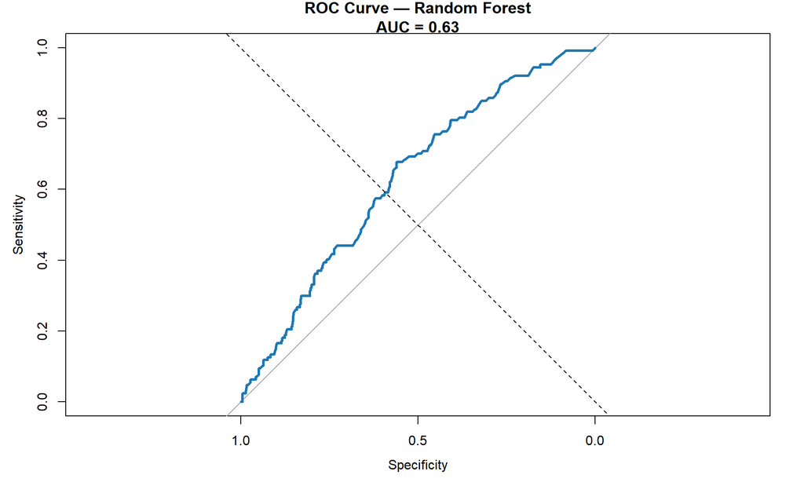

```r
# --------------------------------------------------
# Predictions (Train + Test)
# --------------------------------------------------

train_prob <- predict(
  mx_rf_model,
  newdata = mx_rf_train,
  type = "prob"
)[,2]

mx_rf_test$pred_prob <- predict(
  mx_rf_model,
  newdata = mx_rf_test,
  type = "prob"
)[,2]

# --------------------------------------------------
# ROC and AUC
# --------------------------------------------------

roc_rf <- roc(mx_rf_test$progressed, mx_rf_test$pred_prob)
auc_rf <- auc(roc_rf)

plot(
  roc_rf,
  col="#1F78B4",
  lwd=3,
  main=paste("ROC Curve — Random Forest\nAUC =", round(auc_rf,3))
)

abline(a=0,b=1,lty=2)
```

```r
# --------------------------------------------------
# Optimal Threshold (FROM TRAIN DATA)
# --------------------------------------------------

roc_train <- roc(mx_rf_train$progressed, train_prob)

optimal_threshold <- as.numeric(
  coords(roc_train, x="best", ret="threshold")
)

cat("Optimal Threshold:", optimal_threshold, "\n")
```

```
## Optimal Threshold: 0.59
```

```r
# --------------------------------------------------
# Apply Threshold
# --------------------------------------------------

mx_rf_test$pred_class <- ifelse(
  mx_rf_test$pred_prob >= optimal_threshold,
  1,
  0
)

mx_rf_test$pred_class <- factor(mx_rf_test$pred_class, levels=c(0,1))

# --------------------------------------------------
# Confusion Matrix
# --------------------------------------------------

conf_matrix_rf <- confusionMatrix(
  mx_rf_test$pred_class,
  mx_rf_test$progressed,
  positive="1"
)

conf_matrix_rf
```

```
## Confusion Matrix and Statistics
##
##           Reference
## Prediction   0   1
##          0 719 103
##          1 103  24
##
##                Accuracy : 0.7829
##                  95% CI : (0.7553, 0.8088)
##     No Information Rate : 0.8662
##     P-Value [Acc > NIR] : 1
##
##                   Kappa : 0.0637
##
##  Mcnemar's Test P-Value : 1
##
##             Sensitivity : 0.18898
##             Specificity : 0.87470
##          Pos Pred Value : 0.18898
##          Neg Pred Value : 0.87470
##              Prevalence : 0.13383
##          Detection Rate : 0.02529
##    Detection Prevalence : 0.13383
##       Balanced Accuracy : 0.53184
##
##        'Positive' Class : 1
##
```

```r
# --------------------------------------------------
# Performance Metrics
# --------------------------------------------------

metrics_rf <- tibble(
  Metric=c("Accuracy","Precision","Recall","F1 Score","AUC"),
  Value=c(
    accuracy_vec(mx_rf_test$progressed, mx_rf_test$pred_class),
    precision_vec(mx_rf_test$progressed, mx_rf_test$pred_class, event_level="second"),
    recall_vec(mx_rf_test$progressed, mx_rf_test$pred_class, event_level="second"),
    f_meas_vec(mx_rf_test$progressed, mx_rf_test$pred_class, event_level="second"),
    as.numeric(auc_rf)
  )
)

metrics_rf %>%
  gt() %>%
  tab_header(title="Random Forest Model Performance") %>%
  fmt_number(columns=Value, decimals=4)
```

Random Forest Model Performance

| Metric | Value |
| --- | --- |
| Accuracy | 0.7829 |
| Precision | 0.1890 |
| Recall | 0.1890 |
| F1 Score | 0.1890 |
| AUC | 0.6299 |

```r
# --------------------------------------------------
# Variable Importance
# --------------------------------------------------

var_imp <- importance(mx_rf_model)

var_imp_df <- tibble(
  Variable = rownames(var_imp),
  MeanDecreaseAccuracy = var_imp[,"MeanDecreaseAccuracy"],
  MeanDecreaseGini = var_imp[,"MeanDecreaseGini"]
)

var_imp_df %>%
  arrange(desc(MeanDecreaseAccuracy)) %>%
  gt() %>%
  tab_header(title="Random Forest Variable Importance")
```

Random Forest Variable Importance

| Variable | MeanDecreaseAccuracy | MeanDecreaseGini |
| --- | --- | --- |
| acct_territory_rollup | 16.403586 | 51.99480 |
| title_function | 8.999553 | 118.28608 |
| acct_tier_rollup | 6.319011 | 50.28372 |
| title_seniority | 5.980887 | 98.34271 |
| acct_primary_site_function | 5.923167 | 121.84265 |
| acct_target_industry | 2.877057 | 59.39874 |
| acct_manufacturing_model | 0.683911 | 90.45675 |

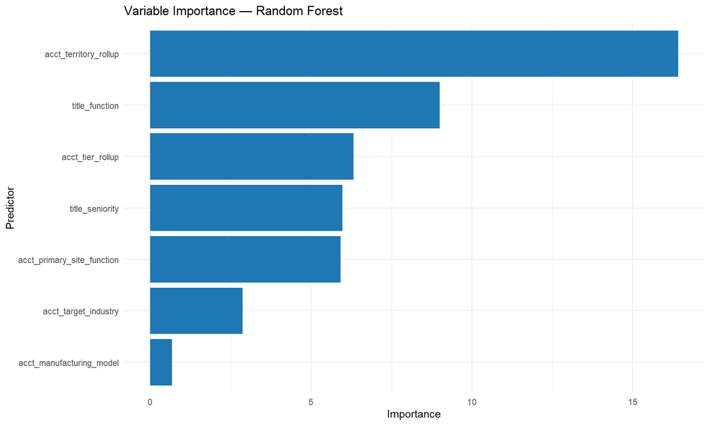

```r
ggplot(var_imp_df,
       aes(x=reorder(Variable, MeanDecreaseAccuracy),
           y=MeanDecreaseAccuracy)) +
  geom_col(fill="#1F78B4") +
  coord_flip() +
  labs(
    title="Variable Importance — Random Forest",
    x="Predictor",
    y="Importance"
  ) +
  theme_minimal()
```

## 12.6 . Model 5: Gradient Boosting / XGBoost

This chunk fits a boosted tree model that focuses on predictive strength and captures nonlinear relationships and interactions that simpler models may miss.

[output not shown]

[output cut: 435 more lines]

[output not shown]

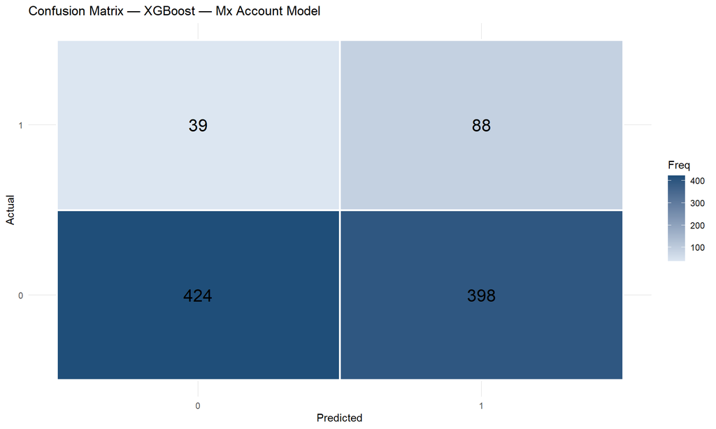

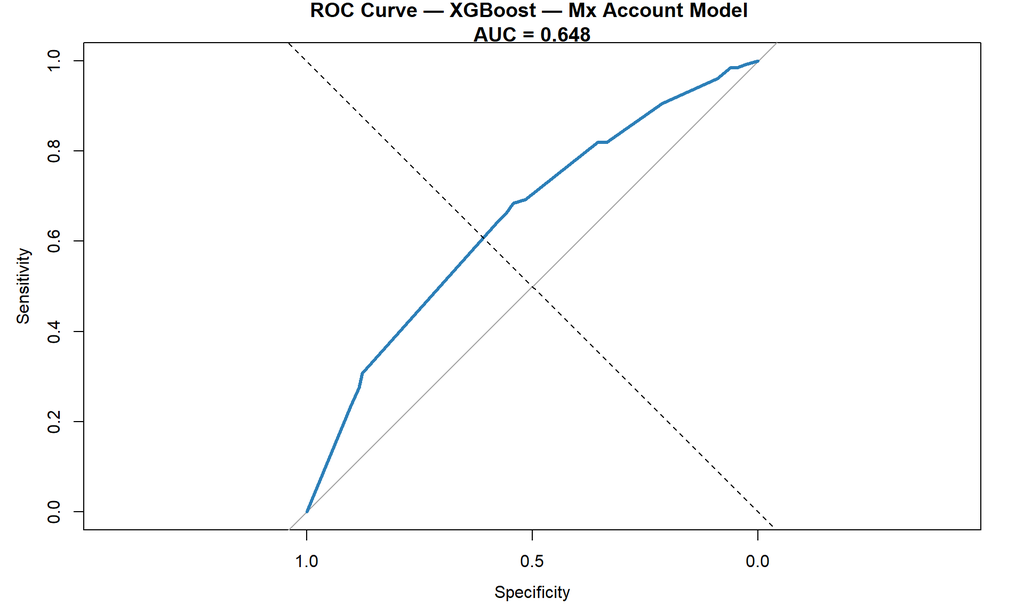

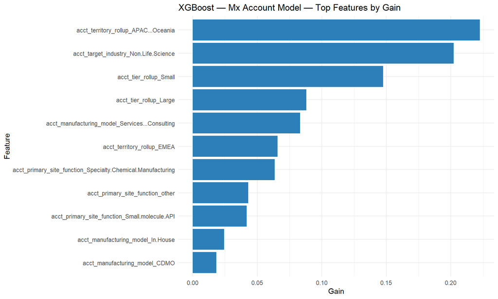

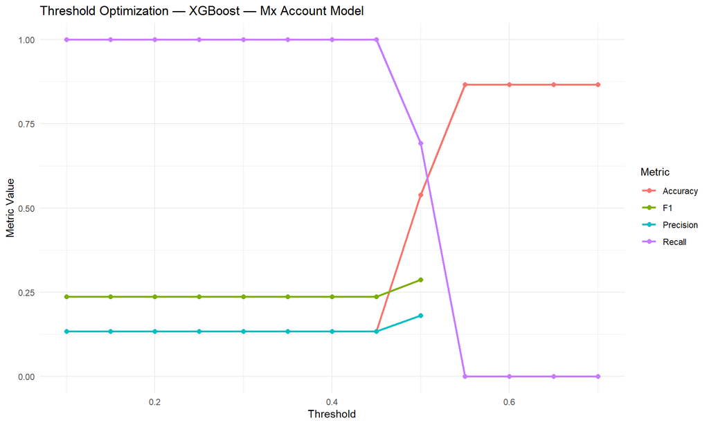

[output not shown]

[output cut: 478 more lines]

[output not shown]

```r
# ==================================================
# Model 5 — XGBoost
# Feature-Engineered Predictive Model
# ==================================================

library(dplyr)
library(tidyr)
library(recipes)
library(xgboost)
library(pROC)
library(caret)
library(yardstick)
library(tibble)
library(gt)
library(ggplot2)
library(scales)

set.seed(123)

# --------------------------------------------------
# Reusable XGBoost Function
# --------------------------------------------------

run_xgb_model <- function(train_df,
                          test_df,
                          outcome_var,
                          predictor_vars,
                          model_title,
                          nfold = 5,
                          nrounds = 500,
                          early_stopping_rounds = 30,
                          eta = 0.05,
                          max_depth = 5,
                          min_child_weight = 8,
                          subsample = 0.8,
                          colsample_bytree = 0.8,
                          gamma = 1) {

  # -----------------------------------------------
  # Keep only required columns
  # -----------------------------------------------

  train_model_data <- train_df %>%
    select(all_of(c(outcome_var, predictor_vars))) %>%
    drop_na()

  test_model_data <- test_df %>%
    select(all_of(c(outcome_var, predictor_vars))) %>%
    drop_na()

  # make outcome numeric 0/1 factor
  train_model_data[[outcome_var]] <- factor(train_model_data[[outcome_var]], levels = c(0, 1))
  test_model_data[[outcome_var]]  <- factor(test_model_data[[outcome_var]], levels = c(0, 1))

  # -----------------------------------------------
  # Recipe for encoding engineered predictors
  # -----------------------------------------------

  xgb_recipe <- recipe(
    as.formula(paste(outcome_var, "~", paste(predictor_vars, collapse = " + "))),
    data = train_model_data
  ) %>%
    step_other(all_nominal_predictors(), threshold = 0.03) %>%
    step_unknown(all_nominal_predictors()) %>%
    step_novel(all_nominal_predictors()) %>%
    step_dummy(all_nominal_predictors(), one_hot = TRUE) %>%
    step_zv(all_predictors())

  xgb_prep <- prep(xgb_recipe, training = train_model_data)

  train_encoded <- bake(xgb_prep, new_data = train_model_data)
  test_encoded  <- bake(xgb_prep, new_data = test_model_data)

  # -----------------------------------------------
  # Create x and y
  # -----------------------------------------------

  train_y <- as.numeric(as.character(train_encoded[[outcome_var]]))
  test_y  <- as.numeric(as.character(test_encoded[[outcome_var]]))

  train_x <- train_encoded %>%
    select(-all_of(outcome_var)) %>%
    as.matrix()

  test_x <- test_encoded %>%
    select(-all_of(outcome_var)) %>%
    as.matrix()

  dtrain <- xgb.DMatrix(data = train_x, label = train_y)
  dtest  <- xgb.DMatrix(data = test_x, label = test_y)

  # -----------------------------------------------
  # Class imbalance handling
  # -----------------------------------------------

  neg_count <- sum(train_y == 0)
  pos_count <- sum(train_y == 1)
  scale_pos_weight_value <- neg_count / pos_count

  # -----------------------------------------------
  # Parameters
  # -----------------------------------------------

  params <- list(
    objective = "binary:logistic",
    eval_metric = "auc",
    eta = eta,
    max_depth = max_depth,
    min_child_weight = min_child_weight,
    subsample = subsample,
    colsample_bytree = colsample_bytree,
    gamma = gamma,
    scale_pos_weight = scale_pos_weight_value
  )

  # -----------------------------------------------
  # Cross-validation
  # -----------------------------------------------

  cv_model <- xgb.cv(
    params = params,
    data = dtrain,
    nrounds = nrounds,
    nfold = nfold,
    stratified = TRUE,
    early_stopping_rounds = early_stopping_rounds,
    verbose = 0,
    maximize = TRUE
  )

  best_nrounds <- max(cv_model$best_iteration, 1)

  # -----------------------------------------------
  # Final model
  # -----------------------------------------------

  xgb_model <- xgb.train(
    params = params,
    data = dtrain,
    nrounds = best_nrounds,
    verbose = 0
  )

  # -----------------------------------------------
  # Predictions
  # -----------------------------------------------

  train_pred_prob <- predict(xgb_model, dtrain)
  test_pred_prob  <- predict(xgb_model, dtest)

  # -----------------------------------------------
  # Threshold from TRAIN ROC
  # -----------------------------------------------

  train_roc <- roc(response = train_y, predictor = train_pred_prob, quiet = TRUE)

  optimal_threshold <- as.numeric(
    coords(train_roc, x = "best", ret = "threshold")
  )

  test_pred_class <- ifelse(test_pred_prob >= optimal_threshold, 1, 0)

  test_pred_class_factor <- factor(test_pred_class, levels = c(0, 1))
  test_y_factor <- factor(test_y, levels = c(0, 1))

  # -----------------------------------------------
  # Confusion matrix
  # -----------------------------------------------

  conf_matrix <- confusionMatrix(
    test_pred_class_factor,
    test_y_factor,
    positive = "1"
  )

  # -----------------------------------------------
  # Metrics
  # -----------------------------------------------

  test_roc <- roc(response = test_y, predictor = test_pred_prob, quiet = TRUE)
  auc_value <- as.numeric(auc(test_roc))

  metrics_tbl <- tibble(
    Metric = c("Accuracy", "Precision", "Recall", "F1 Score", "AUC", "Threshold", "Best CV Rounds"),
    Value = c(
      accuracy_vec(test_y_factor, test_pred_class_factor),
      precision_vec(test_y_factor, test_pred_class_factor, event_level = "second"),
      recall_vec(test_y_factor, test_pred_class_factor, event_level = "second"),
      f_meas_vec(test_y_factor, test_pred_class_factor, event_level = "second"),
      auc_value,
      optimal_threshold,
      best_nrounds
    )
  )

  # -----------------------------------------------
  # Feature importance
  # -----------------------------------------------

  importance_tbl <- xgb.importance(
    feature_names = colnames(train_x),
    model = xgb_model
  )

  # -----------------------------------------------
  # Threshold tuning table on TEST set
  # -----------------------------------------------

  threshold_grid <- seq(0.10, 0.70, by = 0.05)

  threshold_tbl <- lapply(threshold_grid, function(th) {
    pred_class <- factor(ifelse(test_pred_prob >= th, 1, 0), levels = c(0, 1))

    tibble(
      Threshold = th,
      Accuracy = accuracy_vec(test_y_factor, pred_class),
      Precision = precision_vec(test_y_factor, pred_class, event_level = "second"),
      Recall = recall_vec(test_y_factor, pred_class, event_level = "second"),
      F1 = f_meas_vec(test_y_factor, pred_class, event_level = "second")
    )
  }) %>%
    bind_rows()

  # -----------------------------------------------
  # Output section
  # -----------------------------------------------

  cat("\n==================================================\n")
  cat(model_title, "\n")
  cat("==================================================\n\n")

  cat("Training rows used:", nrow(train_model_data), "\n")
  cat("Testing rows used :", nrow(test_model_data), "\n")
  cat("Scale pos weight  :", round(scale_pos_weight_value, 3), "\n")
  cat("Best CV rounds    :", best_nrounds, "\n")
  cat("Train-based threshold:", round(optimal_threshold, 4), "\n\n")

  print(
    metrics_tbl %>%
      gt() %>%
      tab_header(title = paste(model_title, "— Performance Metrics")) %>%
      fmt_number(columns = Value, decimals = 4)
  )

  conf_df <- as.data.frame(conf_matrix$table)

  print(
    ggplot(conf_df, aes(x = Prediction, y = Reference, fill = Freq)) +
      geom_tile(color = "white", linewidth = 1) +
      geom_text(aes(label = Freq), size = 6) +
      scale_fill_gradient(low = "#DCE6F1", high = "#1F4E79") +
      labs(
        title = paste("Confusion Matrix —", model_title),
        x = "Predicted",
        y = "Actual"
      ) +
      theme_minimal()
  )

  plot(
    test_roc,
    col = "#2C7FB8",
    lwd = 3,
    main = paste("ROC Curve —", model_title, "\nAUC =", round(auc_value, 3))
  )
  abline(a = 0, b = 1, lty = 2)

  print(
    importance_tbl %>%
      slice_head(n = 15) %>%
      ggplot(aes(x = reorder(Feature, Gain), y = Gain)) +
      geom_col(fill = "#2C7FB8") +
      coord_flip() +
      labs(
        title = paste(model_title, "— Top Features by Gain"),
        x = "Feature",
        y = "Gain"
      ) +
      theme_minimal()
  )

  # threshold tuning plot
  threshold_long <- threshold_tbl %>%
    pivot_longer(cols = c(Accuracy, Precision, Recall, F1),
                 names_to = "Metric",
                 values_to = "Value")

  print(
    ggplot(threshold_long, aes(x = Threshold, y = Value, color = Metric)) +
      geom_line(linewidth = 1) +
      geom_point(size = 2) +
      labs(
        title = paste("Threshold Optimization —", model_title),
        x = "Threshold",
        y = "Metric Value"
      ) +
      theme_minimal()
  )

  print(
    threshold_tbl %>%
      gt() %>%
      tab_header(title = paste(model_title, "— Threshold Tuning Table")) %>%
      fmt_number(columns = c(Accuracy, Precision, Recall, F1), decimals = 4)
  )

  invisible(list(
    model = xgb_model,
    metrics = metrics_tbl,
    confusion_matrix = conf_matrix,
    roc = test_roc,
    threshold_table = threshold_tbl,
    importance = importance_tbl
  ))
}

# ==================================================
# Step 1 — XGBoost Mx Account Model
# ==================================================

mx_account_train <- train_data %>%
  filter(solution_rollup == "Mx")

mx_account_test <- test_data %>%
  filter(solution_rollup == "Mx")

mx_account_xgb <- run_xgb_model(
  train_df = mx_account_train,
  test_df = mx_account_test,
  outcome_var = "progressed",
  predictor_vars = c(
    "acct_target_industry",
    "acct_manufacturing_model",
    "acct_primary_site_function",
    "acct_tier_rollup",
    "acct_territory_rollup"
  ),
  model_title = "XGBoost — Mx Account Model"
)
```

```r
# ==================================================
# Step 2 — XGBoost Mx Title Model
# ==================================================

mx_title_xgb <- run_xgb_model(
  train_df = mx_account_train,
  test_df = mx_account_test,
  outcome_var = "progressed",
  predictor_vars = c(
    "title_seniority",
    "title_function"
  ),
  model_title = "XGBoost — Mx Title Model"
)
```

[output not shown]

[output cut: 435 more lines]

[output not shown]

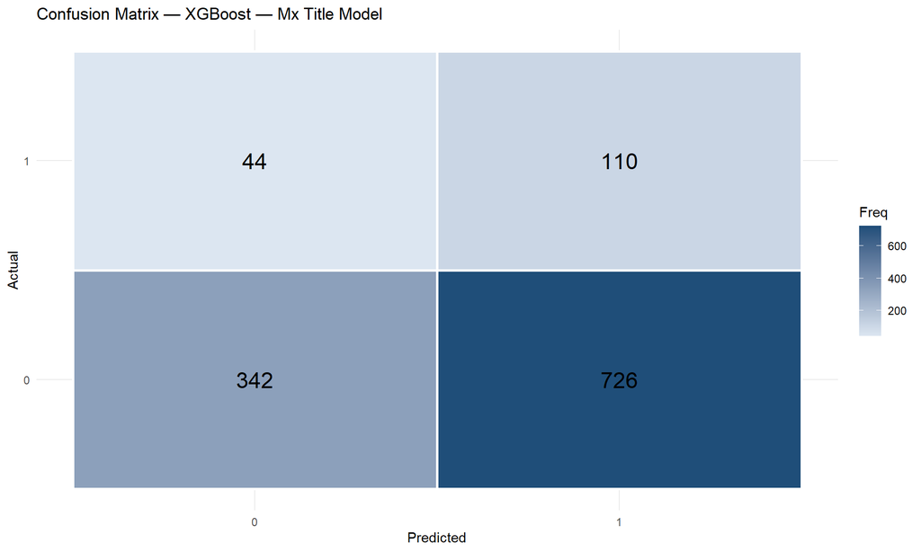

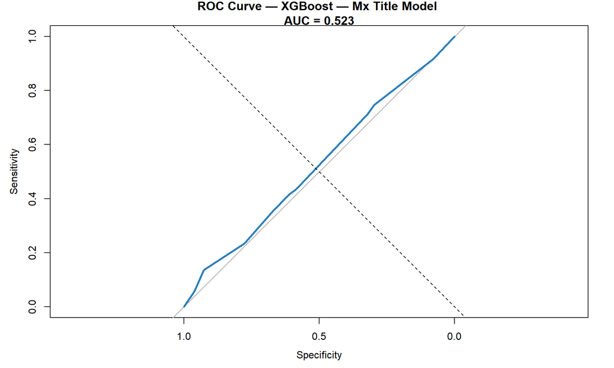

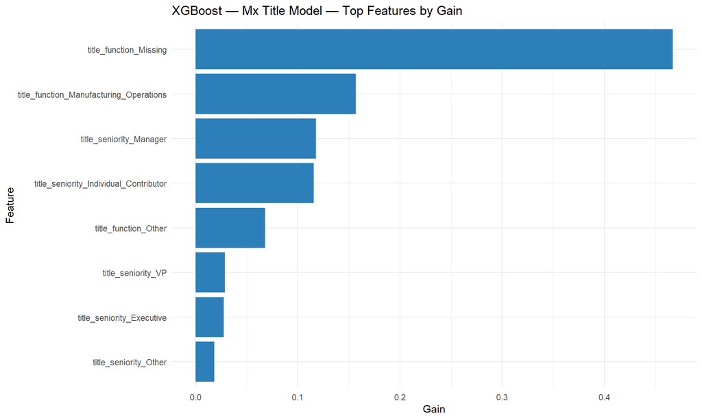

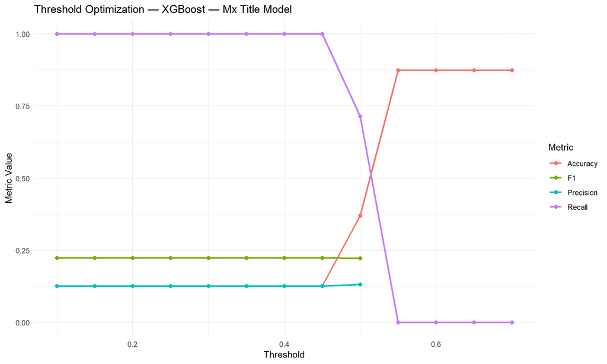

[output not shown]

[output cut: 478 more lines]

[output not shown]

```r
# ==================================================
# Step 3 — XGBoost Mx Combined Model
# ==================================================

mx_combined_xgb <- run_xgb_model(
  train_df = mx_account_train,
  test_df = mx_account_test,
  outcome_var = "progressed",
  predictor_vars = c(
    "acct_target_industry",
    "acct_manufacturing_model",
    "acct_primary_site_function",
    "acct_tier_rollup",
    "acct_territory_rollup",
    "title_seniority",
    "title_function"
  ),
  model_title = "XGBoost — Mx Combined Account + Title Model"
)
```

[output not shown]

[output cut: 435 more lines]

[output not shown]

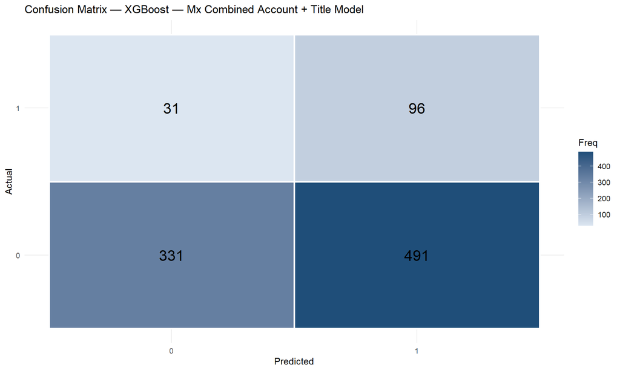

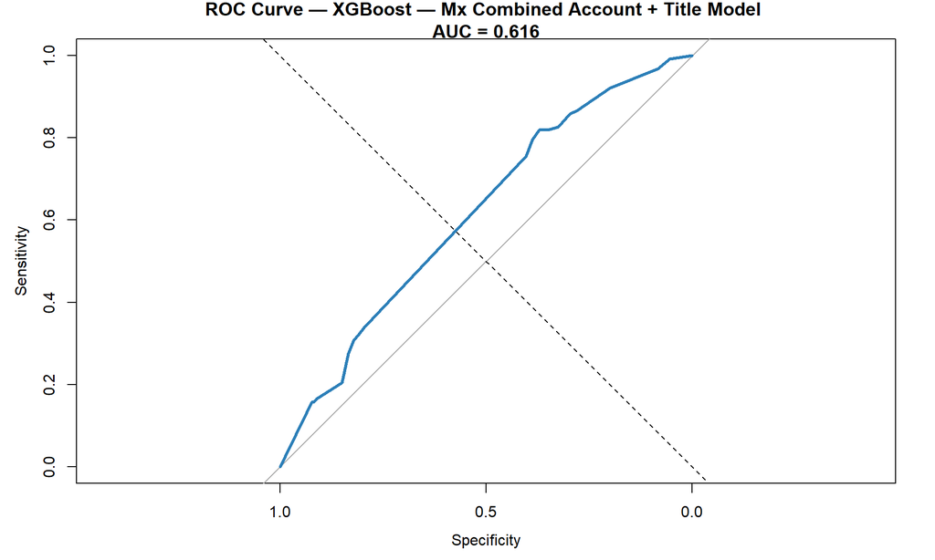

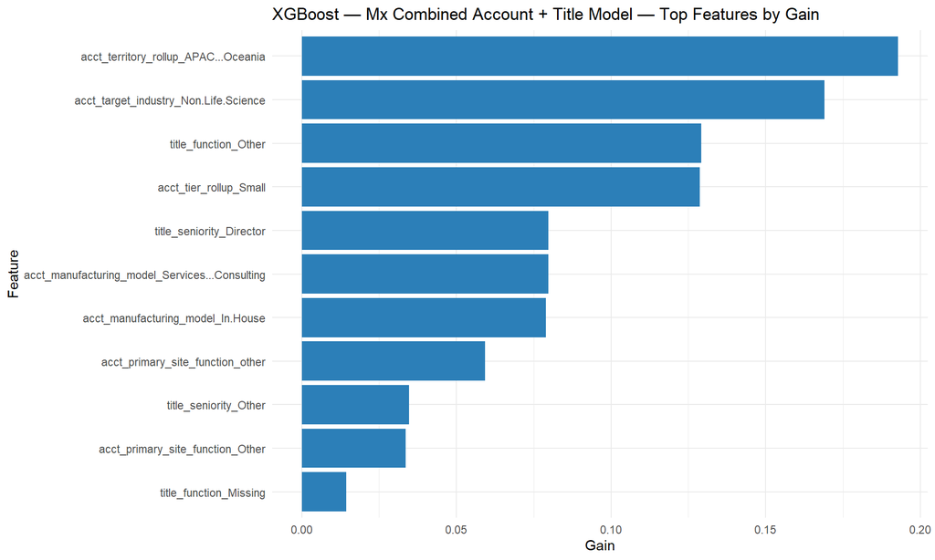

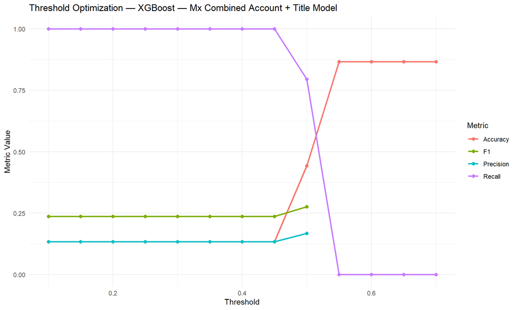

[output not shown]

[output cut: 478 more lines]

[output not shown]

```r
# ==================================================
# Step 4 — XGBoost Mx vs Qx Cross-Sell Model
# ==================================================

cross_train <- train_data %>%
  filter(solution_rollup %in% c("Mx", "Qx")) %>%
  mutate(mx_product = ifelse(solution_rollup == "Mx", 1, 0))

cross_test <- test_data %>%
  filter(solution_rollup %in% c("Mx", "Qx")) %>%
  mutate(mx_product = ifelse(solution_rollup == "Mx", 1, 0))

cross_xgb <- run_xgb_model(
  train_df = cross_train,
  test_df = cross_test,
  outcome_var = "mx_product",
  predictor_vars = c(
    "acct_target_industry",
    "acct_manufacturing_model",
    "acct_primary_site_function",
    "acct_tier_rollup",
    "acct_territory_rollup",
    "title_seniority",
    "title_function"
  ),
  model_title = "XGBoost — Mx vs Qx Cross-Sell Model"
)
```

[output not shown]

[output cut: 435 more lines]

[output not shown]

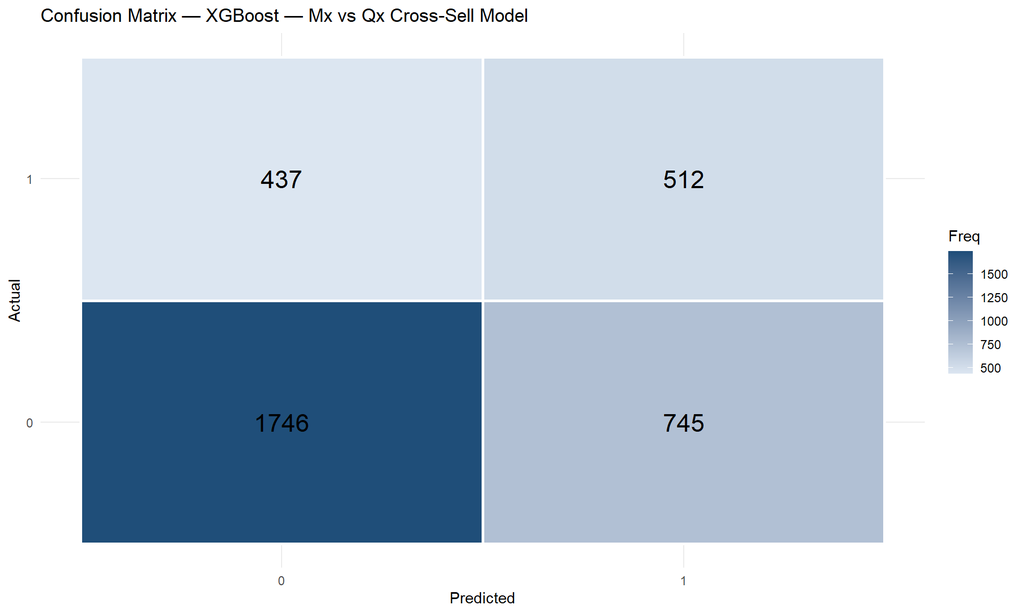

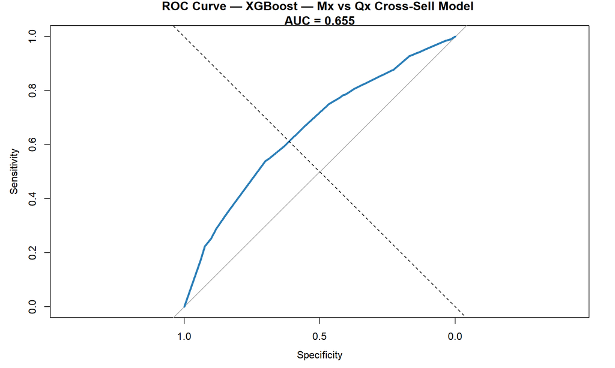

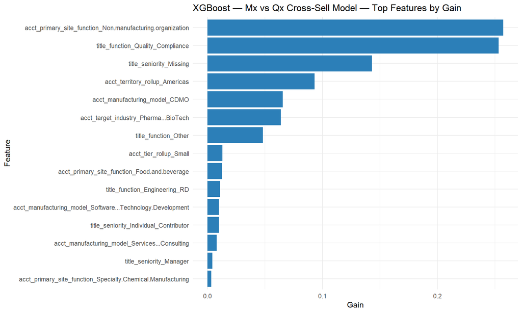

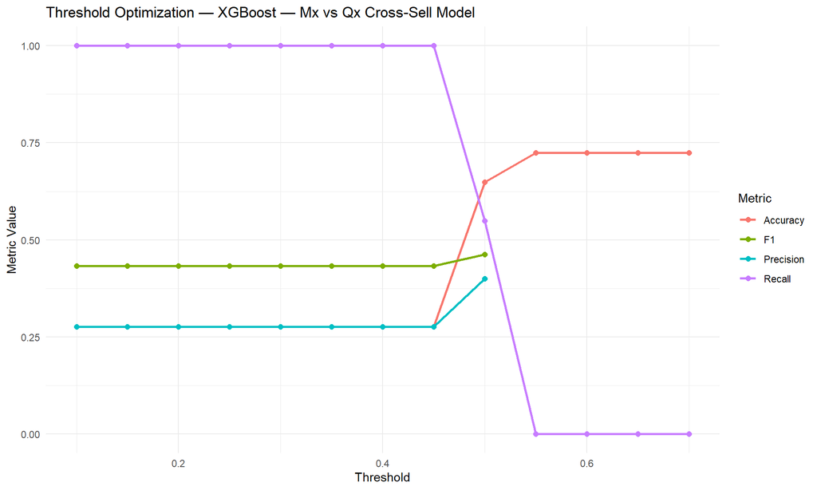

[output not shown]

[output cut: 478 more lines]

[output not shown]

# 13 . Model Comparison

This chunk compares models using classification metrics such as accuracy, precision, recall, F1, and ROC-AUC so the final recommendation balances performance with interpretability.

```r
# ==================================================
# Model Comparison — Performance Summary
# ==================================================

library(dplyr)
library(tidyr)
library(gt)

# --------------------------------------------------
# Extract metrics from each model
# --------------------------------------------------

logistic_metrics <- mx_combined_results$metrics %>%
  mutate(Model = "Logistic Regression")

glmnet_metrics <- mx_combined_glmnet$metrics %>%
  mutate(Model = "Elastic Net (GLMNET)")

tree_metrics <- metrics_tree %>%
  mutate(Model = "Decision Tree")

rf_metrics <- metrics_rf %>%
  mutate(Model = "Random Forest")

xgb_metrics <- mx_combined_xgb$metrics %>%
  mutate(Model = "XGBoost")

# --------------------------------------------------
# Combine all model metrics
# --------------------------------------------------

model_comparison <- bind_rows(
  logistic_metrics,
  glmnet_metrics,
  tree_metrics,
  rf_metrics,
  xgb_metrics
)

# --------------------------------------------------
# Pivot to comparison table
# --------------------------------------------------

comparison_table <- model_comparison %>%
  select(Model, Metric, Value) %>%
  pivot_wider(
    names_from = Metric,
    values_from = Value
  )

# --------------------------------------------------
# Display comparison table
# --------------------------------------------------

comparison_table %>%
  gt() %>%
  tab_header(
    title = "Model Performance Comparison",
    subtitle = "Evaluation using Accuracy, Precision, Recall, F1 Score, and ROC-AUC"
  ) %>%
  fmt_number(
    columns = where(is.numeric),
    decimals = 4
  )
```

Model Performance Comparison

Evaluation using Accuracy, Precision, Recall, F1 Score, and ROC-AUC

| Model | Accuracy | Precision | Recall | F1 Score | AUC | Threshold | Best Lambda | Best CV Rounds |
| --- | --- | --- | --- | --- | --- | --- | --- | --- |
| Logistic Regression | 0.4768 | 0.1649 | 0.7165 | 0.2680 | 0.6367 | 0.1016 | NA | NA |
| Elastic Net (GLMNET) | 0.4632 | 0.1646 | 0.7402 | 0.2693 | 0.6403 | 0.1122 | 0.0047 | NA |
| Decision Tree | 0.5680 | 0.1717 | 0.5827 | 0.2652 | NA | NA | NA | NA |
| Random Forest | 0.7829 | 0.1890 | 0.1890 | 0.1890 | 0.6299 | NA | NA | NA |
| XGBoost | 0.4499 | 0.1635 | 0.7559 | 0.2689 | 0.6157 | 0.5010 | NA | 1.0000 |

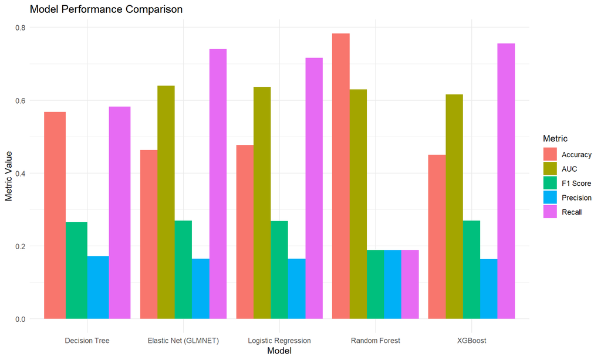

```r
# --------------------------------------------------
# Visualization of Model Performance
# --------------------------------------------------

comparison_long <- model_comparison %>%
  filter(Metric %in% c("Accuracy","Precision","Recall","F1 Score","AUC"))

library(ggplot2)

ggplot(comparison_long,
       aes(x = Model, y = Value, fill = Metric)) +
  geom_col(position = "dodge") +
  labs(
    title = "Model Performance Comparison",
    x = "Model",
    y = "Metric Value"
  ) +
  theme_minimal()
```

# 14 . Executive Analysis and Final Recommendations

## 14.1 . Overview

The objective of this analysis was to understand why the Mx product line progresses qualified leads at a lower rate than Qx, and to develop a data-driven targeting framework that improves Mx conversion performance. The analysis combined descriptive analytics, predictive modeling, and prescriptive recommendations to translate historical lead progression data into actionable commercial strategy.

The findings from this analysis provide a clear framework for improving Mx targeting and strengthening overall commercial effectiveness.

## 14.2 . Descriptive Analytics: Understanding Current Performance Patterns

The descriptive phase examined how lead progression varies across several business dimensions, including product line, industry, manufacturing model, site function, company tier, geography, and buyer titles.

### 14.2.1 . Product Performance Gap

The first key observation is the performance difference between the two products. Qx demonstrates consistently stronger progression rates, while Mx shows lower conversion across most segments. This confirms that the issue is not isolated to a single industry or territory but reflects a broader structural pattern.

### 14.2.2 . Importance of Manufacturing Context

This result highlights an important structural issue in the current targeting strategy. Because Mx is a manufacturing execution solution, outreach directed toward organizations without meaningful manufacturing operations is unlikely to produce strong progression results.

### 14.2.3 . Role of Buyer Personas

Buyer characteristics also influence progression outcomes. Titles associated with Director and Manager levels often demonstrated stronger progression than generic executive outreach. Additionally, functional roles tied to quality management, manufacturing operations, and operational oversight performed more consistently than roles unrelated to manufacturing processes.

These patterns suggest that the most effective Mx buyers are often operational leaders responsible for execution and workflow management rather than purely strategic executive stakeholders.

### 14.2.4 . Industry and Geography

Industry segmentation alone does not fully explain progression outcomes. While life sciences industries remain the natural focus for MasterControl, the analysis indicates that manufacturing structure and buyer relevance are more important predictors than industry classification alone.

## 14.3 . Predictive Analytics: Identifying the Drivers of Mx Progression

The predictive phase translated the descriptive patterns into statistical models designed to estimate the probability that a lead progresses through the sales pipeline.

Several models were evaluated:

```
-   Logistic Regression
-   Elastic-Net Logistic Regression (GLMNET)
-   Decision Tree (CART)
-   Random Forest
-   Gradient Boosting (XGBoost)
```

Each model provides different advantages. Tree-based and boosting models can capture complex interactions and nonlinear relationships, while logistic models provide clearer interpretability.

Why Logistic Regression Was Selected as the Primary Model

Although all models produced useful insights, logistic regression was selected as the primary model for several reasons: 1. Interpretability Logistic regression clearly quantifies how each account or title attribute influences progression probability. This makes it possible to translate statistical outputs into business decisions. 2. Alignment with Client Deliverables The client’s key questions require interpretable relationships between account characteristics and lead progression. Logistic regression allows the analysis to directly answer questions such as: - which industries convert best, - which manufacturing models drive progression, - which job titles represent the strongest buyers. 3. Transparency for Commercial Teams Sales and marketing teams must understand why certain accounts or personas should be prioritized. Logistic regression provides a transparent explanation framework, making it easier to operationalize the results.

Role of Elastic-Net Logistic Regression

Elastic-net logistic regression was used as a supporting model to validate the findings from the primary logistic regression model. Because elastic-net introduces regularization, it helps stabilize estimates and reduce the impact of correlated predictors.

The elastic-net results largely confirmed the same variables identified by logistic regression, strengthening confidence that the observed drivers of progression are not simply artifacts of model specification.

Role of Tree-Based Models

Decision trees, random forests, and XGBoost models were valuable for benchmarking predictive performance and identifying nonlinear patterns. However, they are less interpretable and therefore less suitable as the primary decision framework for this project. Instead, they serve as supporting models that validate the core patterns discovered through logistic analysis.

**Table: Role of Each Model in the Analysis**

| Model | Purpose in Analysis |
| --- | --- |
| Logistic Regression | Primary interpretable model used to identify key drivers of lead progression |
| Elastic Net (GLMNET) | Validation model that applies regularization to stabilize estimates and handle correlated predictors |
| Decision Tree (CART) | Rule-based segmentation model used to identify interpretable decision patterns |
| Random Forest | Ensemble model used to evaluate variable importance and reduce overfitting |
| XGBoost | High-performance gradient boosting model used as a predictive benchmark |

## 14.4 . Prescriptive Analytics: Translating Findings into Business Strategy

The final stage of the analysis translates the descriptive and predictive findings into concrete business recommendations. This section directly addresses the client’s requested deliverables.

# 15 . Client Deliverables and Strategic Recommendations

## 15.1 .Deliverable 1: Which Account Types Should MasterControl Target for Mx?

MasterControl offers two primary enterprise software solutions within its platform: Qx (Quality Excellence) and Mx (Manufacturing Excellence). Qx digitizes quality and compliance processes such as document control, training management, audits, CAPA, and regulatory workflows. Because regulatory compliance is mandatory across many life sciences organizations, Qx has broad applicability across both manufacturing and non-manufacturing companies.

Mx, in contrast, is a manufacturing execution solution (MES) that digitally manages production workflows, electronic batch records, and embedded quality checks within manufacturing processes. Unlike Qx, the value of Mx depends heavily on whether the organization actually operates manufacturing environments. As a result, the potential market for Mx is structurally narrower than that of Qx.

The descriptive and predictive analysis consistently indicates that the strongest opportunities for Mx occur in organizations where manufacturing activity is central to operations.

Based on the analysis, MasterControl should prioritize:

- organizations operating in-house manufacturing environments
- contract manufacturing organizations (CMOs/CDMOs)
- companies where manufacturing execution and production workflows are core operational activities

These organizations have clear operational needs for digital production management, batch traceability, and manufacturing process control, which aligns directly with the value proposition of Mx.

In contrast, accounts that primarily operate as service organizations, consulting firms, or non-manufacturing entities should generally be deprioritized for Mx outreach unless there is explicit evidence that they operate manufacturing facilities.

Industry targeting should remain focused on regulated life sciences sectors, particularly pharmaceutical, biotechnology, and medical device organizations. However, the analysis shows that manufacturing structure is a stronger predictor of Mx progression than industry classification alone.

Company size also influences progression patterns. Small and medium-tier organizations often demonstrate strong potential because they tend to have fewer legacy systems and may adopt digital manufacturing solutions more quickly than very large enterprises.

## 15.2 .Deliverable 2: Which Job Titles Convert Best for Mx?

While account structure determines whether an organization is a good candidate for Mx, buyer personas determine whether a lead progresses through the sales pipeline.

The analysis indicates that the most effective Mx buyers are mid-to-senior operational leaders responsible for manufacturing and production processes.

The strongest converting personas include:

- Directors of Manufacturing
- Directors of Quality
- Manufacturing Operations Managers
- Quality Systems Managers
- Operational Excellence Leaders

These roles are closely tied to production workflows, manufacturing performance, and operational compliance. As a result, they are more likely to recognize the operational efficiency and traceability benefits provided by Mx.

This finding aligns with the fundamental positioning of Mx as a manufacturing execution platform. Because the product embeds quality checks directly into manufacturing processes and digitizes batch execution workflows, the individuals responsible for day-to-day operations are the most natural buyers.

Senior executive roles, such as C-level leaders, may still influence final purchasing decisions, but the analysis suggests that initial progression is more strongly associated with operational decision-makers who directly experience manufacturing challenges.

Therefore, MasterControl should prioritize operational leaders early in the sales process, while engaging executive stakeholders later in the buying cycle.

## 15.3 .Deliverable 3: How Does the Ideal Mx Buyer Differ from the Ideal Qx Buyer?

The analysis reveals a fundamental difference between the buyer profiles of Qx and Mx.

Qx serves as a quality management system (QMS) that supports compliance activities such as document control, training, audit readiness, and risk management. Because regulatory compliance requirements apply broadly across regulated industries, Qx can be adopted by a wide range of organizations regardless of whether they actively manufacture products. ￼

As a result, Qx buyers tend to come from quality assurance, regulatory, and compliance functions, and the solution converts well across both manufacturing and non-manufacturing organizations.

Mx, on the other hand, supports manufacturing execution and production traceability, which makes it highly dependent on operational manufacturing environments. Its buyers are therefore more specialized.

Key differences between the two buyer profiles include:

**Table: Comparison of Qx and Mx Buyer Profiles**

| Dimension | Qx Buyer Profile | Mx Buyer Profile |
| --- | --- | --- |
| Core Value | Compliance & audit readiness | Digital manufacturing execution |
| Manufacturing Requirement | Not required | Required |
| Primary Buyer Functions | Quality / Regulatory | Manufacturing / Operations |
| Sensitivity to Site Function | Low | Very High |

Because of these differences, applying the same targeting strategy to both products can dilute Mx performance. Qx can succeed with broad compliance-oriented outreach, while Mx requires more focused targeting toward operational manufacturing environments.

## 15.4 . Deliverable 4: Which Accounts and Titles Represent Cross-Sell Opportunities?

Cross-sell opportunities occur when both product value propositions align within the same organization.

The strongest cross-sell candidates are organizations that already maintain formal quality systems while also operating active manufacturing environments. In these cases, Because many regulated manufacturers first adopt quality management solutions before digitizing manufacturing execution, Qx deployments can naturally serve as an entry point for future Mx adoption.

The best cross-sell scenarios include:

- organizations already adopting quality management systems but operating manufacturing facilities
- operational leaders responsible for both manufacturing performance and quality compliance
- companies transitioning from quality-focused digital systems toward fully integrated manufacturing execution platforms

In these cases, Qx adoption may naturally create demand for Mx capabilities, particularly when organizations seek to link quality management with production workflows.

This cross-product relationship reflects the architecture of the MasterControl platform, which connects quality management, manufacturing execution, and asset management within a unified compliance-focused system.

## 15.5 .Deliverable 5: What Is the Expected Impact of Improved Targeting?

By improving targeting precision, MasterControl can significantly improve the efficiency of Mx sales efforts.

Current performance suggests that a substantial portion of Mx leads originate from accounts or personas that are not strongly aligned with the product’s core use case. When outreach is directed toward non-manufacturing organizations or purely quality-focused roles, the probability of progression declines.

## 15.6 . Business Value of the Analytical Framework

Beyond answering the immediate business questions, this analysis establishes a repeatable framework for commercial decision-making.

The models and segmentation insights developed in this project can support:

- improved lead scoring models
- better segmentation of outbound marketing campaigns
- clearer definitions of Ideal Customer Profiles (ICPs) for both Qx and Mx
- stronger alignment between sales, marketing, and product teams

Most importantly, this framework shifts MasterControl’s approach from volume-based lead generation to precision targeting based on empirical progression data.

Instead of focusing primarily on generating more leads, the company can focus on identifying the right organizations, the right operational environments, and the right buyer personas for Mx adoption.

# 16 . Mx Lead Prioritization Framework

This section translates the predictive modeling results into a direct action framework for MasterControl’s sales team. Using the combined logistic regression model, all Mx leads are scored and ranked into three priority tiers based on their estimated probability of progression.

```r
# Setup and scoring
library(dplyr)
library(gt)

mx_all_leads <- analysis_all %>%
  filter(solution_rollup == "Mx") %>%
  select(progressed, acct_target_industry, acct_manufacturing_model,
    acct_primary_site_function, acct_tier_rollup, acct_territory_rollup,
    title_seniority, title_function) %>%
  drop_na()

for(v in names(mx_combined_results$model$xlevels)) {
  mx_all_leads[[v]] <- factor(mx_all_leads[[v]],
    levels = mx_combined_results$model$xlevels[[v]])
}

mx_all_leads <- mx_all_leads %>% drop_na()

mx_all_leads$pred_prob <- predict(mx_combined_results$model,
  newdata = mx_all_leads, type = "response")

mx_all_leads <- mx_all_leads %>%
  mutate(priority_tier = case_when(
    pred_prob >= 0.25 ~ "Tier 1 — High Priority",
    pred_prob >= 0.15 ~ "Tier 2 — Medium Priority",
    TRUE             ~ "Tier 3 — Low Priority"))
```

```r
tier_summary <- mx_all_leads %>%
  group_by(priority_tier) %>%
  summarise(Lead_Count = n(),
    Actual_Conversion = round(mean(progressed == 1) * 100, 1),
    .groups = "drop") %>%
  mutate(
    Pct_of_Pipeline  = round(Lead_Count / sum(Lead_Count) * 100, 1),
    Lift_vs_Baseline = round(Actual_Conversion - mean(mx_all_leads$progressed == 1) * 100, 1))

tier_summary %>%
  gt() %>%
  tab_header(title = "Mx Lead Prioritization Framework",
    subtitle = "Model-driven tiers showing expected conversion lift vs. baseline")
```

Mx Lead Prioritization Framework

Model-driven tiers showing expected conversion lift vs. baseline

| priority_tier | Lead_Count | Actual_Conversion | Pct_of_Pipeline | Lift_vs_Baseline |
| --- | --- | --- | --- | --- |
| Tier 1 — High Priority | 310 | 32.9 | 9.9 | 19.4 |
| Tier 2 — Medium Priority | 783 | 17.0 | 24.9 | 3.5 |
| Tier 3 — Low Priority | 2051 | 9.2 | 65.2 | -4.3 |

```r
tier1_profile <- mx_all_leads %>%
  filter(priority_tier == "Tier 1 — High Priority") %>%
  summarise(
    Top_Industry  = names(sort(table(acct_target_industry),    decreasing=TRUE))[1],
    Top_Mfg_Model = names(sort(table(acct_manufacturing_model),decreasing=TRUE))[1],
    Top_Site_Func = names(sort(table(acct_primary_site_function),decreasing=TRUE))[1],
    Top_Tier      = names(sort(table(acct_tier_rollup),        decreasing=TRUE))[1],
    Top_Seniority = names(sort(table(title_seniority),         decreasing=TRUE))[1],
    Top_Function  = names(sort(table(title_function),          decreasing=TRUE))[1])

tier1_profile %>%
  gt() %>%
  tab_header(title = "Tier 1 Lead Profile — Most Common Characteristics")
```

Tier 1 Lead Profile — Most Common Characteristics

| Top_Industry | Top_Mfg_Model | Top_Site_Func | Top_Tier | Top_Seniority | Top_Function |
| --- | --- | --- | --- | --- | --- |
| Pharma & BioTech | In-House | Other | Small | Manager | Other |

```r
baseline_conv <- round(mean(mx_all_leads$progressed == 1) * 100, 1)
tier1_conv    <- tier_summary %>%
  filter(priority_tier == "Tier 1 — High Priority") %>% pull(Actual_Conversion)
tier1_count   <- tier_summary %>%
  filter(priority_tier == "Tier 1 — High Priority") %>% pull(Lead_Count)

tibble(
  Metric = c("Overall Mx Baseline Conversion", "Tier 1 Conversion Rate",
    "Lift (percentage points)", "Tier 1 Lead Count"),
  Value  = c(paste0(baseline_conv, "%"), paste0(tier1_conv, "%"),
    paste0("+", tier1_conv - baseline_conv, " pp"), as.character(tier1_count))
) %>%
  gt() %>%
  tab_header(title = "Estimated Impact of Tier 1 Targeting",
    subtitle = "What MasterControl should prioritize differently going forward")
```

Estimated Impact of Tier 1 Targeting

What MasterControl should prioritize differently going forward

| Metric | Value |
| --- | --- |
| Overall Mx Baseline Conversion | 13.5% |
| Tier 1 Conversion Rate | 32.9% |
| Lift (percentage points) | +19.4 pp |
| Tier 1 Lead Count | 310 |

# 17 . Final Conclusion

The analysis confirms that Mx underperformance is largely driven by targeting misalignment rather than inherent product limitations.

Organizations with active manufacturing operations and operational decision-makers represent the strongest opportunities for Mx adoption. By prioritizing these accounts and personas, MasterControl can improve conversion efficiency and better align commercial effort with actual product-market fit.

Among the predictive models evaluated, logistic regression and elastic-net logistic regression provide the best balance between predictive performance and interpretability. Logistic regression serves as the primary analytical model because it clearly explains the relationship between account characteristics, buyer roles, and progression outcomes, making it the most useful framework for guiding business decisions.

In practical terms, the analysis demonstrates that improving account fit and buyer alignment can significantly strengthen Mx pipeline efficiency without requiring additional lead generation, allowing MasterControl to scale growth through smarter targeting rather than larger lead volumes.

By applying these insights, MasterControl can improve the precision of its Mx targeting strategy, increase lead progression efficiency, and strengthen long-term adoption of the Mx product line.

# 18 . Group Member Contributions

This project was completed through collaborative work by all group members. Each member independently developed a modeling file exploring different analytical approaches to address the business problem. These individual modeling efforts included experimentation with multiple predictive techniques and interpretation of results related to lead progression for the Mx and Qx product lines.

Following this process, the group reviewed the outputs collectively and selected the modeling approach that best aligned with the project objectives and the client deliverables. The final analysis presented in this report integrates insights from these individual modeling efforts and reflects the collective evaluation of model interpretability, business relevance, and analytical rigor.

In addition to modeling, group members contributed to data preparation, exploratory analysis, interpretation of results, development of business recommendations, and preparation of the final report.

# 19 . AI Log

Artificial Intelligence tools were used in a limited and supportive capacity during this project.

AI assistance was primarily used to help with:

```
•   debugging and refining R code,
•   structuring certain visualization components,
•   verifying interpretation of statistical outputs, and
•   improving clarity in documentation and explanation of analytical results.
```

All modeling decisions, interpretation of results, and final recommendations were reviewed and validated by the project team to ensure accuracy and alignment with the analytical objectives of the project.